# Exploratory Data Analysis of BHP Group (2005–2025)

This project analyzes the long-term performance of **BHP Group Limited (ASX: BHP)**, one of the world’s largest mining companies.  
The dataset consists of monthly stock price history from Jan 2005 to Aug 2025.

The goals of this analysis are to:

- Summarize BHP’s long-term returns and growth (CAGR).
- Examine price trends and link them to major global events.
- Measure risk through volatility and drawdowns.
- Explore long- vs short-term cycles using moving averages.

**Company Overview**

BHP Group Limited (BHP) is a diversified natural resources company. It is engaged in mining of copper, silver, zinc, molybdenum, uranium and gold, iron ore, metallurgical coal and energy coal.

**Principal Activity**

Exploration, development and production of oil and gas; Mining of iron ore, metallurgical coal and energy coal, copper, silver, zinc, molybdenum, uranium and gold.

***Dataset Timeframe and Source***

Monthly Price History Jan 31st 2005 - August 29th 2025, sourced from DataAnalysis Premium

***Known Big Key Events***

2008 GFC, 2015 commodity crash, 2020 COVID, 2021 rally

# Case Study

*How do global commodity cycles affect the financial and stock performance of BHP?*

# Executive Summary

BHP has grown steadily over the past 20 years (CAGR ~6%), but its performance is highly cyclical, with volatility and drawdowns closely tied to global commodity market shocks.

```python
# External Libraries
# !pip install pandas
# !pip install numpy
# !pip install cleaningbox
# !pip install matplotlib

import pandas as pd
import numpy as np
from cleaningbox import cleaningbox
import matplotlib.pyplot as plt
import matplotlib.dates as mdates
import matplotlib.ticker as mtick
```

```python
cb = cleaningbox()
cb.load_data(dataset="pricehistory-monthlyadj.xlsx", missingvalues=[])
cb.find_missing_values(verbose="true")
df = cb.get_data()
df.head(10)
```

```
✓ Dataset is clean
```

|  | ASX Code | Company Name | Date | Close | Volume | Market Capitalisation($m) | Shares on Issue |
| --- | --- | --- | --- | --- | --- | --- | --- |
| 0 | BHP | BHP Group Limited | 29/08/2025 | 43.19 | 156704444 | 219358.26 | 5078913175 |
| 1 | BHP | BHP Group Limited | 31/07/2025 | 39.25 | 187913083 | 199232.70 | 5075992235 |
| 2 | BHP | BHP Group Limited | 30/06/2025 | 36.75 | 200140217 | 186542.71 | 5075992235 |
| 3 | BHP | BHP Group Limited | 30/05/2025 | 38.25 | 175290608 | 194156.70 | 5075992235 |
| 4 | BHP | BHP Group Limited | 30/04/2025 | 38.19 | 183378634 | 193852.14 | 5075992235 |
| 5 | BHP | BHP Group Limited | 31/03/2025 | 38.20 | 188089750 | 193823.03 | 5073901188 |
| 6 | BHP | BHP Group Limited | 28/02/2025 | 39.04 | 149739013 | 198085.10 | 5073901188 |
| 7 | BHP | BHP Group Limited | 31/01/2025 | 39.95 | 126026124 | 202702.35 | 5073901188 |
| 8 | BHP | BHP Group Limited | 31/12/2024 | 39.55 | 127837557 | 200672.79 | 5073901188 |
| 9 | BHP | BHP Group Limited | 29/11/2024 | 40.57 | 152785428 | 205848.17 | 5073901188 |

## 1. Descriptive Statistics

To understand BHP’s long-term performance, a statistics summary is calculated for the stock’s closing price, as well as the **Compound Annual Growth Rate (CAGR)** from 2005–2025.

- **CAGR** tells us the steady annualized rate of growth (or decline) over the entire 20-year period.
- Along with min, max, mean, and standard deviation, this gives a baseline picture of BHP’s stock performance.

```python
df = cb.get_data()
print(f"""'Close' Col. Summary Stats (to 2DP):
    Min: {round(df['Close'].min(),2)}
    Max: {round(df['Close'].max(),2)}
    Mean: {round(df['Close'].mean(),2)}
    Median: {round(df['Close'].median(),2)}
    Std Dev: {round(df['Close'].std(),2)}
     """)

# CAGR Value | 2005 - 2025 CAGR %
last_price = df["Close"].iloc[0]
first_price = df["Close"].iloc[-1]
year_difference = 2025 - 2005 + 7/12
CAGR = (last_price / first_price) ** (1/year_difference) - 1
print(f"First price (31/1/2005): {first_price} | Last price (29/8/2025): {last_price}")
print(f"2005-2025 GACR Rate: {round(CAGR * 100, 2)}%")

# GACR Rate Sanity Check
print("\nGACR Rate Sanity Check")

predicted_last = first_price * ((1+CAGR))** year_difference
print("Actual Last Price: " + str(last_price))
print("Predicted Last Price: " + str(round(predicted_last, 2)))
```

```
'Close' Col. Summary Stats (to 2DP):
    Min: 12.94
    Max: 50.41
    Mean: 30.47
    Median: 30.12
    Std Dev: 8.41

First price (31/1/2005): 13.125 | Last price (29/8/2025): 43.19
2005-2025 GACR Rate: 5.96%

GACR Rate Sanity Check
Actual Last Price: 43.19
Predicted Last Price: 43.19
```

***Monthly Returns***

```python
df["Monthly Returns"] = df["Close"].pct_change()

monthly_returns_min = df["Monthly Returns"].min()
monthly_returns_max = df["Monthly Returns"].max()
monthly_returns_mean = df["Monthly Returns"].mean()
monthly_returns_stdev = df["Monthly Returns"].std()

min_index = df.index[df["Monthly Returns"] == monthly_returns_min][0]
max_index = df.index[df["Monthly Returns"] == monthly_returns_max][0]
min_date = df.loc[min_index, "Date"]
max_date = df.loc[max_index, "Date"]

print("'Monthly Returns' Col. Summary Stats:\n"
        f"Worst Return: {monthly_returns_min:.2%} | {min_date}\n"
        f"Best Return: {monthly_returns_max:.2%} | {max_date}\n"
        f"Average Return: {monthly_returns_mean:.2%}\n"
        f"Std. Dev. Return: {monthly_returns_stdev:.2%}")
```

```
'Monthly Returns' Col. Summary Stats:
Worst Return: -18.47% | 31/03/2016
Best Return: 33.55% | 29/08/2008
Average Return: -0.22%
Std. Dev. Return: 7.35%
```

**Descriptive Statistics Conclusion**

Over the 20-year period (2005–2025), BHP’s stock price grew from **$13.13** to **$43.19**, achieving a steady **Compound Annual Growth Rate (CAGR) of ~6%**.  
The price ranged between a **low of $12.94** and a **high of $50.41**, with an average value near **$30** and a standard deviation of **$8.41**, highlighting significant long-term volatility.

Taken together, these statistics show that while BHP delivered meaningful long-term growth, it did so through a volatile path marked by sharp booms and deep downturns.

## 2. Volatility and Price Analysis

BHP’s stock price shows a cyclical pattern over the 2005–2025 period, with sharp rises followed by deep declines. Volatility, measured as the 12-month rolling standard deviation of returns, clearly spikes around major global and commodity-related events.

Overall, the analysis shows that BHP’s performance is tightly linked to global macroeconomic cycles. Prices tend to recover strongly after downturns, but volatility consistently spikes during crises — reinforcing that long-term growth has come with significant short-term risk.

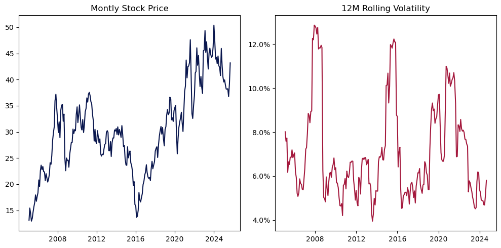

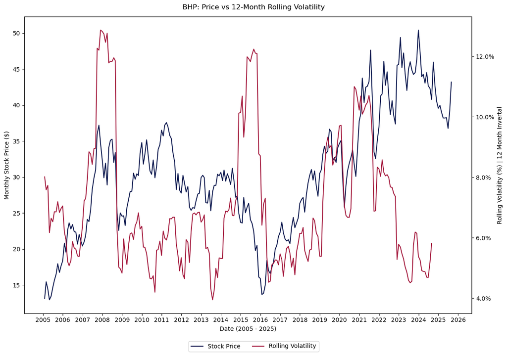

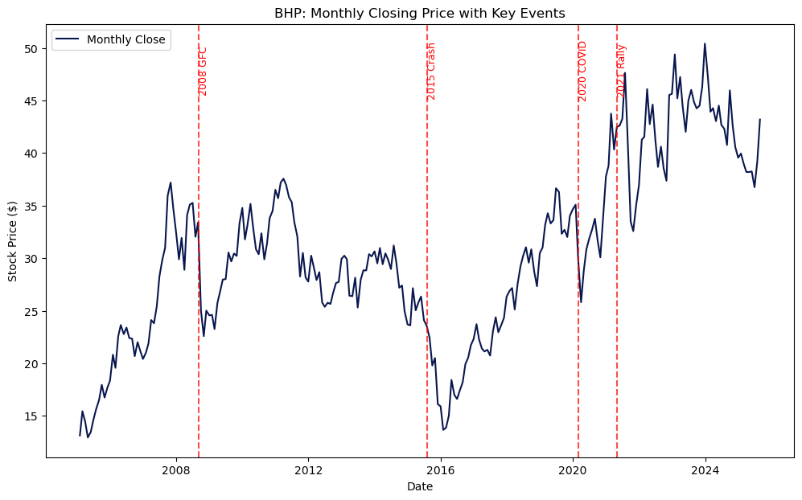

```python
df["Date"] = pd.to_datetime(df["Date"], dayfirst=True)
### Rolling Volatility ###
df["Rolling Volatility"] = df["Monthly Returns"].rolling(12).std() # 12 Month Range

### Rolling Volatility & Price ###
fig, axes = plt.subplots(1, 2, figsize=(10, 5))

axes[0].plot(df['Date'], df['Close'], '#0A174E')
axes[0].set_title("Montly Stock Price")
axes[1].plot(df['Date'], df['Rolling Volatility'], '#A4193D')
axes[1].yaxis.set_major_formatter(mtick.PercentFormatter(1))
axes[1].set_title("12M Rolling Volatility")

plt.tight_layout()
plt.show()

### Rolling Volatility vs Price ###
fig, ax1 = plt.subplots(figsize=(12, 8))

ax1.plot(df["Date"], df["Close"], color='#0A174E', label="Stock Price")
ax1.xaxis.set_major_locator(mdates.YearLocator(base=1))
ax1.set_xlabel("Date (2005 - 2025)")
ax1.set_ylabel("Monthly Stock Price ($)", color='black')
ax1.tick_params(axis='y', labelcolor = 'black')


ax2 = ax1.twinx()
ax2.plot(df["Date"], df["Rolling Volatility"], color='#A4193D', label="Rolling Volatility")
ax2.yaxis.set_major_formatter(mtick.PercentFormatter(1))
ax2.set_ylabel("Rolling Volatility (%) | 12 Month Invertal", color='black')
ax2.tick_params(axis='y', labelcolor = 'black')

fig.suptitle("BHP: Price vs 12-Month Rolling Volatility")
fig.tight_layout()
fig.legend(loc='upper center', bbox_to_anchor=(0.5, 0), ncol=2)
plt.show()

plt.figure(figsize=(12, 7))
plt.plot(df["Date"], df["Close"], label="Monthly Close", color="#0A174E")

# Event markers
events = {
    "2008 GFC": "2008-09-01",
    "2015 Crash": "2015-08-01",
    "2020 COVID": "2020-03-01",
    "2021 Rally": "2021-05-01"
}

for label, date in events.items():
    plt.axvline(pd.to_datetime(date), color="red", linestyle="--", alpha=0.7)
    plt.text(pd.to_datetime(date), df["Close"].max()*0.95, label,
             rotation=90, verticalalignment="center", color="red", fontsize=9)

plt.xlabel("Date")
plt.ylabel("Stock Price ($)")
plt.title("BHP: Monthly Closing Price with Key Events")
plt.legend()
plt.show()
```

## 3. Drawdowns

The largest drawdown in BHP’s stock price over 2005–2025 occurred between **March 2011** and **January 2016**, where the stock fell by **63.6%** (from 37.56 to 13.67).

This downturn coincided with the collapse in global commodity prices, particularly iron ore and coal, as demand from China slowed.

BHP did not fully recover its 2011 peak until **December 2020**, showing that investors endured nearly a decade-long drawdown period.

This highlights the cyclicality of resource companies. Strong booms are often followed by extended busts before recovery.

```
Max Drawdown: -63.61%
From 2011-03-31 ($37.56) to 2016-01-29 ($13.67)
Recovered by 2020-12-31
```

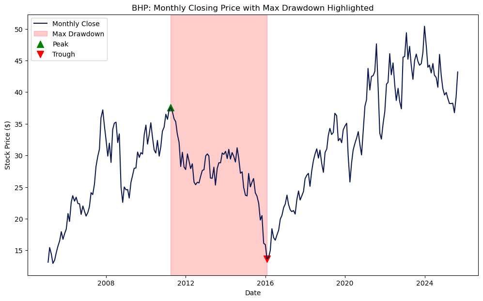

```python
df = df.sort_values("Date").reset_index(drop=True)

df["Peak"] = df["Close"].cummax()
df["Drawdown"] = (df["Close"] - df["Peak"]) / df["Peak"]

# Trough (worst point)
trough_idx = df["Drawdown"].idxmin()
trough_date = df.loc[trough_idx, "Date"]
trough_price = df.loc[trough_idx, "Close"]
worst_drawdown = df.loc[trough_idx, "Drawdown"]

# Peak before trough
peak_idx = df.loc[:trough_idx, "Close"].idxmax()
peak_date = df.loc[peak_idx, "Date"]
peak_price = df.loc[peak_idx, "Close"]

recovery = df.loc[trough_idx:, "Close"] >= peak_price
if recovery.any():
    recovery_idx = recovery.idxmax()
    recovery_date = df.loc[recovery_idx, "Date"]
else:
    recovery_date = None

print(f"Max Drawdown: {worst_drawdown:.2%}")
print(f"From {peak_date.date()} (${peak_price:.2f}) "
      f"to {trough_date.date()} (${trough_price:.2f})")
if recovery_date:
    print(f"Recovered by {recovery_date.date()}")
else:
    print("Not yet recovered")

plt.figure(figsize=(12, 7))
plt.plot(df["Date"], df["Close"], label="Monthly Close", color="#0A174E")

# Shade drawdown region
plt.axvspan(peak_date, trough_date, color="red", alpha=0.2, label="Max Drawdown")

# Highlight peak & trough points
plt.scatter(peak_date, peak_price, color="green", marker="^", s=100, label="Peak")
plt.scatter(trough_date, trough_price, color="red", marker="v", s=100, label="Trough")

plt.xlabel("Date")
plt.ylabel("Stock Price ($)")
plt.title("BHP: Monthly Closing Price with Max Drawdown Highlighted")
plt.legend()
plt.show()
```

## 4. 📊 Moving Averages (12M vs 36M)

To identify medium- and long-term stock trends, a **12-month moving average (MA12)** and a **36-month moving average (MA36)** were calculated.

- **Golden Cross** (green triangle): occurs when the short-term MA12 crosses above the long-term MA36, often viewed as a bullish (positive) signal.
- **Death Cross** (red triangle): occurs when MA12 crosses below MA36, often viewed as a bearish (negative) signal.

#### Conclusion:

Moving averages successfully captured BHP’s cyclical nature — long rallies often ended with death crosses, while recoveries tended to start with golden crosses. However, like all technical signals, these patterns should be interpreted alongside fundamentals (e.g., commodity prices, global demand).

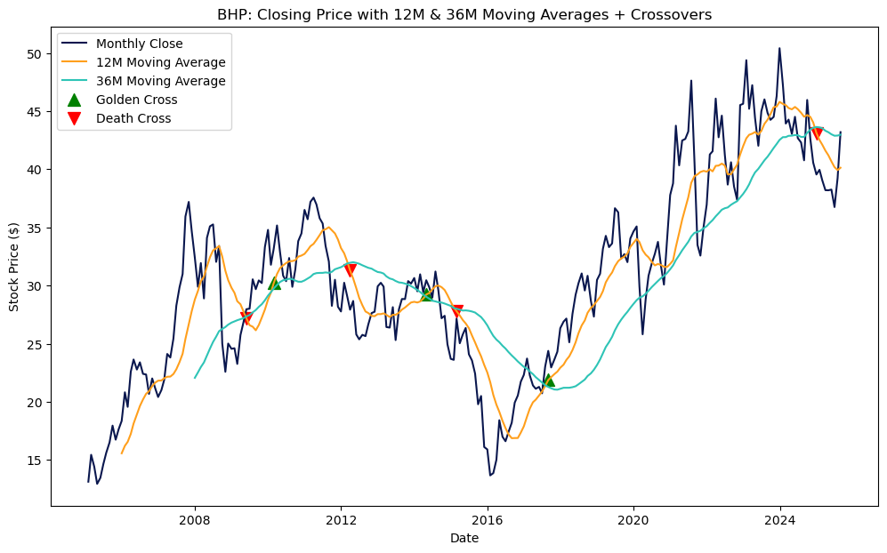

```python
df["MA12"] = df["Close"].rolling(window=12).mean()   # 12-month
df["MA36"] = df["Close"].rolling(window=36).mean()   # 36-month
df["Crossover"] = df["MA12"] - df["MA36"]

golden = df[(df["Crossover"] > 0) & (df["Crossover"].shift(1) <= 0)]

death = df[(df["Crossover"] < 0) & (df["Crossover"].shift(1) >= 0)]
plt.figure(figsize=(12, 7))
plt.plot(df["Date"], df["Close"], label="Monthly Close", color="#0A174E")
plt.plot(df["Date"], df["MA12"], label="12M Moving Average", color="#FF9F1C")
plt.plot(df["Date"], df["MA36"], label="36M Moving Average", color="#2EC4B6")

plt.scatter(golden["Date"], golden["MA12"], marker="^", color="green", s=100, label="Golden Cross")
plt.scatter(death["Date"], death["MA12"], marker="v", color="red", s=100, label="Death Cross")

plt.xlabel("Date")
plt.ylabel("Stock Price ($)")
plt.title("BHP: Closing Price with 12M & 36M Moving Averages + Crossovers")
plt.legend()
plt.show()
```

## 5. Final Table & Conclussion

```python
df.head(100)
# df.to_excel('bhp_final.xlsx', index=False)
```

|  | ASX Code | Company Name | Date | Close | Volume | Market Capitalisation($m) | Shares on Issue | Monthly Returns | Rolling Volatility | Peak | Drawdown | MA12 | MA36 | Crossover |
| --- | --- | --- | --- | --- | --- | --- | --- | --- | --- | --- | --- | --- | --- | --- |
| 0 | BHP | BHP Group Limited | 2005-01-31 | 13.125 | 193281753 | 47023.89 | 3582772683 | -0.149935 | 0.080163 | 13.125 | 0.000000 | NaN | NaN | NaN |
| 1 | BHP | BHP Group Limited | 2005-02-28 | 15.440 | 341865362 | 55318.73 | 3582772683 | 0.071032 | 0.075882 | 15.440 | 0.000000 | NaN | NaN | NaN |
| 2 | BHP | BHP Group Limited | 2005-03-31 | 14.416 | 332907829 | 51648.18 | 3582772683 | 0.114065 | 0.077347 | 15.440 | -0.066321 | NaN | NaN | NaN |
| 3 | BHP | BHP Group Limited | 2005-04-29 | 12.940 | 394821110 | 46359.29 | 3582772683 | -0.038347 | 0.061722 | 15.440 | -0.161917 | NaN | NaN | NaN |
| 4 | BHP | BHP Group Limited | 2005-05-31 | 13.456 | 388938234 | 48209.07 | 3582772683 | -0.081000 | 0.066457 | 15.440 | -0.128497 | NaN | NaN | NaN |
| ... | ... | ... | ... | ... | ... | ... | ... | ... | ... | ... | ... | ... | ... | ... |
| 95 | BHP | BHP Group Limited | 2012-12-31 | 29.929 | 149125922 | 96121.42 | 3211691105 | -0.010121 | 0.065190 | 37.560 | -0.203168 | 27.538750 | 31.161028 | -3.622278 |
| 96 | BHP | BHP Group Limited | 2013-01-31 | 30.235 | 160811382 | 97105.80 | 3211691105 | 0.011069 | 0.066030 | 37.560 | -0.195021 | 27.538750 | 31.118000 | -3.579250 |
| 97 | BHP | BHP Group Limited | 2013-02-28 | 29.904 | 162999042 | 96043.70 | 3211691105 | 0.131570 | 0.067584 | 37.560 | -0.203834 | 27.603917 | 31.027694 | -3.423778 |
| 98 | BHP | BHP Group Limited | 2013-03-28 | 26.427 | 185073339 | 84876.97 | 3211691105 | 0.001820 | 0.056423 | 37.560 | -0.296406 | 27.479500 | 30.785000 | -3.305500 |
| 99 | BHP | BHP Group Limited | 2013-04-30 | 26.379 | 189961133 | 84721.52 | 3211691105 | -0.062513 | 0.056831 | 37.560 | -0.297684 | 27.288583 | 30.604611 | -3.316028 |

100 rows × 14 columns

## Final Conclusion

Over the 2005–2025 period, BHP’s stock demonstrated **steady long-term growth** (CAGR ~6%), but this came with periods of intense volatility and sharp drawdowns.

- **Descriptive statistics** showed a strong overall performance, with the price rising from *~$13* in 2005 to ~$43 in 2025, despite an average monthly return close to zero.
- **Trend analysis** highlighted clear links between global events (2008 GFC, 2015 commodity crash, 2020 COVID shock, and 2021 rally) and price movements.
- **Volatility analysis** revealed that major spikes in risk consistently aligned with these crises, showing BHP’s exposure to global commodity cycles.
- **Drawdowns** quantified the impact of downturns — the largest, from 2011 to 2016, wiped out more than 60% of value before full recovery in 2020.
- **Moving averages** confirmed BHP’s cyclical nature, with golden and death crosses marking transitions between growth and decline phases.

### Advise

BHP’s long-term growth has rewarded investors, but its performance is highly cyclical, strongly tied to global commodity markets. The stock is prone to sharp downturns during global crises but has consistently recovered over time. For investors, this highlights the importance of long-term holding horizons* and awareness of commodity-driven risks.